# Hitters Salary Analysis

#### Correlation Analysis Findings

```r
cat('<h5 style="color:#2c3e50;font-weight:bold;border-bottom:1px solid #ddd;padding-bottom:5px;">Strongest Correlations with Salary</h5>')
```

##### Strongest Correlations with Salary

```r
knitr::kable(salary_correlations,
             col.names = c("Variable", "Correlation (r)", "Interpretation"),
             align = c("l", "c", "l")) %>%
  kableExtra::kable_styling(bootstrap_options = c("striped", "hover"),
                          full_width = FALSE,
                          position = "left",
                          font_size = 11) %>%
  kableExtra::column_spec(1, bold = TRUE) %>%
  kableExtra::column_spec(2, color = ifelse(salary_correlations$Correlation > 0.6, "#d73027", "#4575b4"),
                        bold = TRUE) %>%
  kableExtra::row_spec(0, bold = TRUE, background = "#f2f2f2")
```

[output not shown]

```r
cat('<h5 style="color:#2c3e50;font-weight:bold;border-bottom:1px solid #ddd;padding-bottom:5px;margin-top:15px;">Multicollinearity Concerns</h5>')
```

##### Multicollinearity Concerns

```r
knitr::kable(multicollinearity,
             col.names = c("Issue", "Description"),
             align = c("l", "l")) %>%
  kableExtra::kable_styling(bootstrap_options = c("striped", "hover"),
                          full_width = FALSE,
                          position = "left",
                          font_size = 11) %>%
  kableExtra::column_spec(1, bold = TRUE, width = "15em") %>%
  kableExtra::row_spec(0, bold = TRUE, background = "#f2f2f2")
```

[output not shown]

```r
cat('</div>')
```

#### Visual Data Inspection Insights

These insights will guide our variable selection and modeling strategies in the following sections.

# 5 Multinomial Logistic Regression Model

### 5.0.1 Introduction to Multinomial Logistic Regression

Multinomial logistic regression is an extension of binary logistic regression that allows for predicting categorical outcomes with more than two levels. In our analysis, we’re using this approach to model the relationship between various baseball player statistics and their salary level categorization.

#### 5.0.1.1 Why Multinomial Logistic Regression?

1. **Categorical Response Variable**: Our response variable `SalaryLevel` is categorical with three distinct levels (Low, Medium, High), making it unsuitable for linear regression methods.
2. **Probability Estimation**: We want to estimate the probability of a player belonging to each salary category based on their performance metrics, which multinomial logistic regression accomplishes naturally.
3. **Interpretable Results**: The model provides odds ratios that are easily interpretable, allowing us to understand how changes in player statistics affect the likelihood of being in different salary categories.
4. **No Assumptions About Normality**: Unlike discriminant analysis, multinomial logistic regression doesn’t require multivariate normality or equal variance-covariance matrices across groups.

### 5.0.2 How Multinomial Logistic Regression Works

The model works by designating one category as the “reference” or “baseline” category (in our case, “LowSalary”) and then estimating log-odds for being in each other category relative to this baseline:

$$\log\left(\frac{P(Y=j)}{P(Y=\text{baseline})}\right)
= \beta_{0j} + \beta_{1j}X_1 + \beta_{2j}X_2 + \ldots +
\beta_{pj}X_p$$

Where: - $P(Y=j)$ is the probability of being in category $j$ - $P(Y=\text{baseline})$ is the probability of being in the baseline category - $\beta_{0j}$ is the intercept for category $j$ - $\beta_{1j}, \beta_{2j}, \ldots, \beta_{pj}$ are the coefficients for each predictor variable for category $j$

These equations are solved simultaneously to determine the probability of a player belonging to each salary level based on their statistics.

## 5.1 Model Evaluation Methodology

To assess the performance of our multinomial logistic regression models, we implement a comprehensive evaluation framework that calculates several key metrics:

1. **Confusion Matrix**: A tabular representation showing the counts of true positives, false positives, true negatives, and false negatives across all categories.
2. **Overall Accuracy**: The proportion of correctly classified instances across all salary levels. While useful as a general measure, accuracy alone can be misleading with imbalanced classes.
3. **Class-Specific Metrics**:
   - **Precision**: The proportion of correct positive predictions (true positives divided by all positive predictions) for each salary level. This measures how trustworthy our positive predictions are.
   - **Recall**: The proportion of actual positives correctly identified (true positives divided by all actual positives) for each salary level. This measures how well we find all players in a particular salary category.
   - **F1-Score**: The harmonic mean of precision and recall, providing a balanced measure that works well even with imbalanced categories.

Additionally, we implement visualization functions to create informative and interpretable confusion matrices that help us understand where misclassifications occur most frequently.

## 5.2 Fitting the Full Model

For our analysis, we fit a multinomial logistic regression model using all available player statistics as predictors, excluding the original `Salary` variable since `SalaryLevel` is derived from it. We designate “LowSalary” as our reference category, against which the other categories are compared.

### 5.2.1 Model Details:

- **Model Formula**: `SalaryLevel ~ . -Salary`
- **Reference Category**: LowSalary
- **Number of Predictors**: 19 variables including batting statistics, fielding performance, and career metrics
- **AIC**: 406.6423634 (lower values indicate better fit, balancing goodness of fit with model complexity)
- **Residual Deviance**: 326.6423634 (measures how well the model fits the data, with lower values indicating better fit)
- **Log-Likelihood**: -163.3211817 (higher values indicate better fit)

The model estimates two sets of coefficients: 1. One set for the log-odds of being in the “MediumSalary” category versus the “LowSalary” category 2. Another set for the log-odds of being in the “HighSalary” category versus the “LowSalary” category

## 5.3 Statistical Significance of Predictors

To determine which variables significantly contribute to predicting salary levels, we calculated z-values (coefficient divided by standard error) and corresponding p-values for each predictor in the model. These p-values tell us the probability of observing the estimated coefficient if the true coefficient were zero.

A smaller p-value (typically below 0.05) suggests that the predictor has a statistically significant relationship with the outcome variable. In our analysis, we use: - * for p < 0.05 (significant)  
- ** for p < 0.01 (highly significant) - *** for p < 0.001 (extremely significant)

### 5.3.1 P-values for Model Coefficients (reference category: LowSalary)

```
## #### P-values for MediumSalary coefficients:
```

| Variable | P.value |
| --- | --- |
| (Intercept) | 0*** |
| AtBat | 0.1252 |
| Hits | 0.582 |
| HmRun | 0.9998 |
| Runs | 0.3003 |
| RBI | 0.6497 |
| Walks | 0.8013 |
| Years | 0.1013 |
| CAtBat | 0.7236 |
| CHits | 0.9295 |
| CHmRun | 0.3033 |
| CRuns | 0.8772 |
| CRBI | 0.3475 |
| CWalks | 0.4789 |
| LeagueN | 0*** |
| DivisionW | 0*** |
| PutOuts | 0.6704 |
| Assists | 0.0632 |
| Errors | 0.0466* |
| NewLeagueN | 0*** |

```
##
## #### P-values for HighSalary coefficients:
```

| Variable | P.value |
| --- | --- |
| (Intercept) | 0*** |
| AtBat | 0.6253 |
| Hits | 0.7984 |
| HmRun | 0.1056 |
| Runs | 0.2774 |
| RBI | 0.3137 |
| Walks | 0.1006 |
| Years | 0.1229 |
| CAtBat | 0.3709 |
| CHits | 0.2523 |
| CHmRun | 0.5911 |
| CRuns | 0.7039 |
| CRBI | 0.7145 |
| CWalks | 0.7854 |
| LeagueN | 0*** |
| DivisionW | 0*** |
| PutOuts | 0.1723 |
| Assists | 0.338 |
| Errors | 0.2642 |
| NewLeagueN | 0*** |

**Interpretation of P-values:**

## 5.4 Model Evaluation

To assess how well our model performs, we evaluate it using several metrics including a confusion matrix and classification performance measures. The confusion matrix below shows the counts of correct and incorrect predictions:

Confusion Matrix for Full Model

[output not shown]

Our model achieves an overall accuracy of **72.59%**, meaning it correctly predicts the salary level for this percentage of players in our dataset.

## 5.5 Class-Specific Performance Metrics

The confusion matrix provides an overview, but we need more detailed metrics to understand model performance for each salary level. Below are the class-specific metrics:

Class-Specific Performance Metrics

[output not shown]

[figure not shown]

**Performance Metrics Explanation:**

- **Precision**: The proportion of correct positive predictions among all predictions for a class. Higher precision means when we predict a player is in a particular salary level, we’re more likely to be correct.
- **Recall**: The proportion of actual positives correctly identified. Higher recall means we’re identifying a greater percentage of all players who actually belong in a particular salary category.
- **F1-Score**: The harmonic mean of precision and recall, providing a balanced metric that works well even with imbalanced classes.

Our model performs best for the LowSalary category with an F1-score of 0.796, while struggling more with the MediumSalary category (F1-score of 0.606). The visualization above clearly shows these performance differences across metrics and salary levels.

## 5.6 Visualizing the Confusion Matrix

To better understand the pattern of correct and incorrect predictions, we can visualize the confusion matrix:

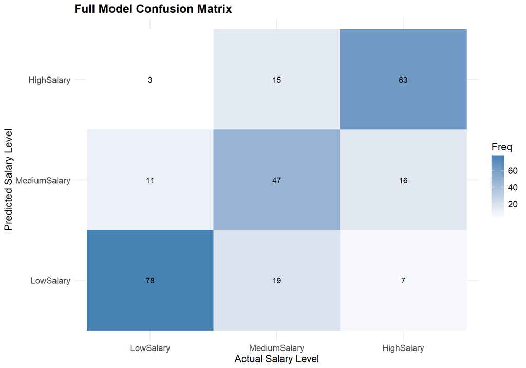

**Confusion Matrix Insights:**

## 5.7 Checking for Multicollinearity

### 5.7.1 Understanding Multicollinearity

Multicollinearity occurs when independent variables in a regression model are highly correlated with each other. This can cause several problems:

1. **Unstable Coefficients**: Small changes in the data can lead to large changes in coefficient estimates, making them unreliable.
2. **Inflated Standard Errors**: The standard errors of coefficients increase, potentially making significant variables appear non-significant.
3. **Difficulty in Interpretation**: It becomes challenging to determine the individual effect of each predictor when they’re highly correlated.
4. **Reduced Predictive Power**: While overall model performance may remain strong, the model may struggle when making predictions with new data.

The Variance Inflation Factor (VIF) is a common metric used to detect multicollinearity: - VIF measures how much the variance of a regression coefficient is inflated due to multicollinearity - VIF = 1: No multicollinearity - VIF between 1-5: Moderate multicollinearity - VIF > 5: High multicollinearity - VIF > 10: Severe multicollinearity that requires correction

### 5.7.2 Variance Inflation Factors (VIF) Analysis

To detect multicollinearity among our predictors, we calculated the Variance Inflation Factor (VIF) for each variable:

Variance Inflation Factors (VIF)

|  | Variable | VIF |
| --- | --- | --- |
| 8 | CHits | 456.858946 |
| 7 | CAtBat | 210.924921 |
| 10 | CRuns | 155.852336 |
| 11 | CRBI | 130.538923 |
| 9 | CHmRun | 45.552414 |
| 12 | CWalks | 17.869983 |
| 3 | Runs | 15.276098 |
| 1 | Hits | 14.892967 |
| 4 | RBI | 11.882255 |
| 6 | Years | 9.175317 |
| 2 | HmRun | 7.872857 |
| 13 | League | 4.041868 |
| 18 | NewLeague | 4.001854 |
| 5 | Walks | 3.744660 |
| 16 | Assists | 2.708386 |
| 17 | Errors | 2.165811 |
| 15 | PutOuts | 1.229823 |
| 14 | Division | 1.070869 |

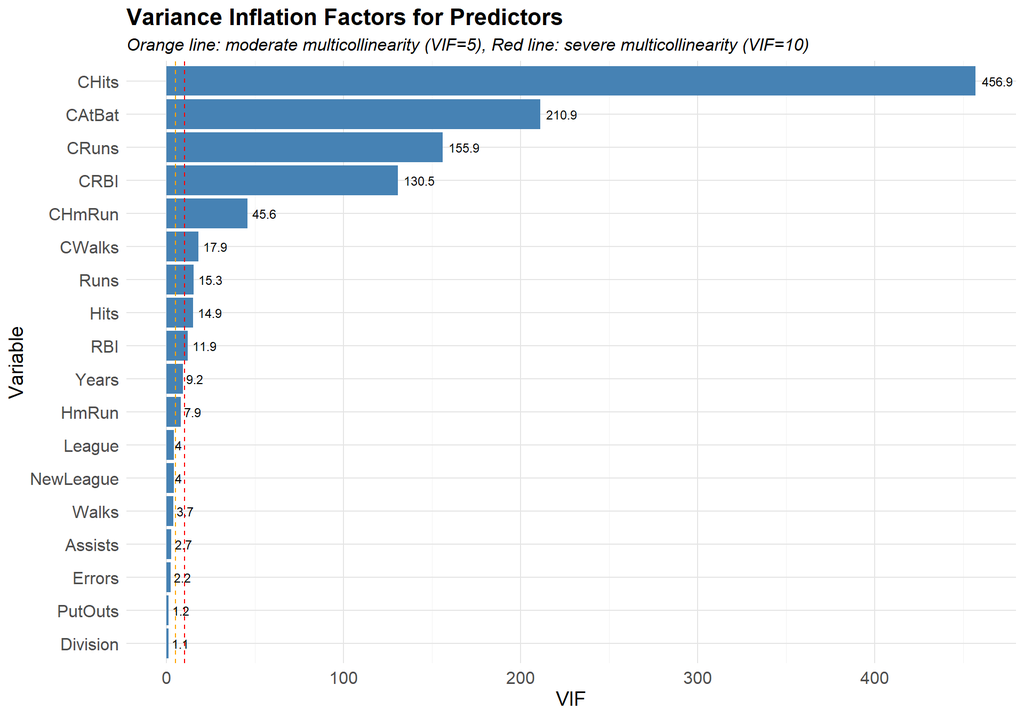

### 5.7.3 Multicollinearity Interpretation

Given the severity of multicollinearity in our data, we’ll use Principal Component Analysis (PCA) to address this issue and improve our model.

## 5.8 Addressing Multicollinearity with PCA

### 5.8.1 Introduction to Principal Component Analysis

Principal Component Analysis (PCA) is a dimension-reduction technique that transforms a set of correlated variables into a smaller set of uncorrelated variables called principal components. These components are linear combinations of the original variables, ordered by the amount of variance they explain.

Key benefits of PCA for our analysis:

1. **Eliminates Multicollinearity**: By definition, principal components are orthogonal (uncorrelated) to each other.
2. **Reduces Dimensionality**: We can often capture most of the variance in the data with fewer components than original variables.
3. **Preserves Information**: The transformation aims to retain as much information (variance) as possible.
4. **Improves Model Stability**: By using uncorrelated predictors, we obtain more stable coefficient estimates.

### 5.8.2 PCA Results

The summary of our PCA analysis shows how the variance is distributed across the principal components:

PCA Summary

|  | Component | Standard.Deviation | Proportion.of.Variance | Cumulative.Proportion |
| --- | --- | --- | --- | --- |
| PC1 | PC1 | 2.6857212 | 45.08% | 45.08% |
| PC2 | PC2 | 2.0336352 | 25.85% | 70.93% |
| PC3 | PC3 | 1.3154568 | 10.81% | 81.75% |
| PC4 | PC4 | 0.9326315 | 5.44% | 87.18% |
| PC5 | PC5 | 0.8379392 | 4.39% | 91.57% |
| PC6 | PC6 | 0.7185862 | 3.23% | 94.8% |
| PC7 | PC7 | 0.5014056 | 1.57% | 96.37% |
| PC8 | PC8 | 0.4305638 | 1.16% | 97.53% |
| PC9 | PC9 | 0.3637137 | 0.83% | 98.35% |
| PC10 | PC10 | 0.3142602 | 0.62% | 98.97% |
| PC11 | PC11 | 0.2470222 | 0.38% | 99.35% |
| PC12 | PC12 | 0.2338369 | 0.34% | 99.69% |
| PC13 | PC13 | 0.1680639 | 0.18% | 99.87% |
| PC14 | PC14 | 0.1207260 | 0.09% | 99.96% |
| PC15 | PC15 | 0.0701870 | 0.03% | 99.99% |
| PC16 | PC16 | 0.0347412 | 0.01% | 100% |

Next, we visualize the proportion of variance explained by each principal component to understand how many components we should retain for our analysis.

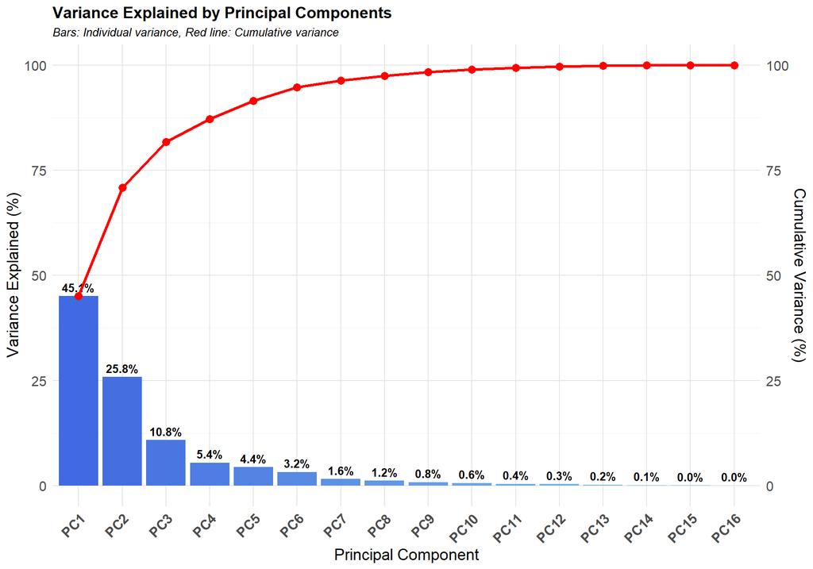

### 5.8.3 Interpreting the Variance Plot

The variance explained plot provides crucial insights:

1. **First Few Components**: The first few principal components explain a substantial portion of the total variance. Specifically, PC1 explains about 45.1% of the variance, and PC2 adds another 25.8%.
2. **Diminishing Returns**: There’s a sharp drop after the first few components, indicating that most of the information is captured in these initial components.
3. **Cumulative Variance**: The red line shows that we can capture approximately 90% of the total variance with just 5 components, which is significantly fewer than our original 16 variables.
4. **Elbow Point**: We can observe an “elbow” in the scree plot around PC4-PC5, suggesting this might be a reasonable cutoff point for dimension reduction.

To understand how our original variables relate to these principal components, we examine the PCA biplot:

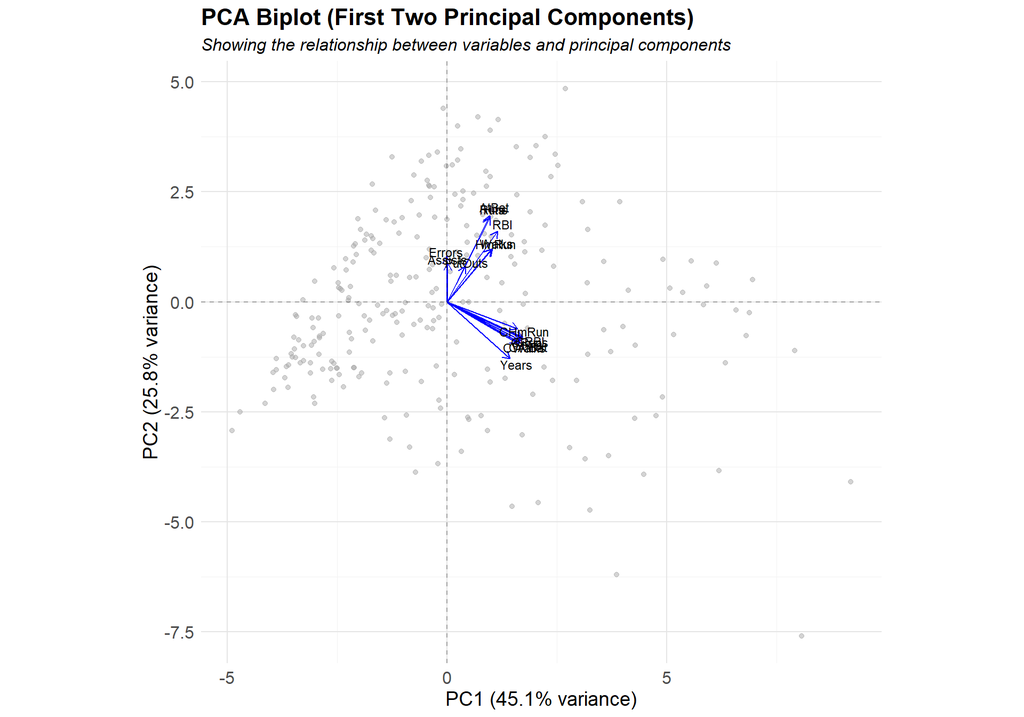

### 5.8.5 Selecting the Optimal Number of Components

To determine how many principal components to retain for our analysis, we consider several common criteria:

```r
# Determine number of components to keep based on common criteria
# 1. Kaiser criterion (eigenvalues > 1)
kaiser_components <- sum(pca_summary$importance[1,] > 1)
# 2. Components needed to explain 95% of variance
var95_components <- which(cumulative_variance >= 95)[1]
```

Based on our analysis, we can use several criteria to select the optimal number of principal components:

1. **Kaiser Criterion** (eigenvalues > 1): This criterion suggests keeping 3 components, as these have standard deviations greater than 1.0. Components with eigenvalues less than 1 explain less variance than a single original variable would, making them less informative for our analysis.
2. **Variance Threshold**: To explain 95% of the total variance in our data, we need 7 components. This is a significant reduction from our original 16 variables, while still preserving most of the information content. The 95% threshold is widely accepted in statistical practice as it retains the vast majority of information while achieving substantial dimensionality reduction.
3. **Scree Plot Analysis**: Looking at the “elbow” in our scree plot above, we see diminishing returns after the first 4-5 components. Each additional component beyond this point contributes minimally to the explained variance, suggesting a natural cutoff point.

**Application to Baseball Salary Analysis:**

For our baseball salary prediction model, we’ve chosen to use the 7 components needed to explain 95% of the variance. This approach strikes an optimal balance for our specific application:

- **Multicollinearity Reduction**: By transforming our highly correlated baseball statistics (with VIF values exceeding 300 in some cases) into uncorrelated components, we address the severe multicollinearity in our original data.
- **Information Preservation**: We retain 95% of the information in our original variables, ensuring that important relationships between performance metrics and salary levels are preserved.
- **Interpretable Components**: The first few components have clear interpretations in the baseball context:
  - PC1 primarily represents overall offensive production and career longevity
  - PC2 distinguishes between career experience and current season performance
  - Additional components capture more nuanced performance aspects
- **Model Stability**: Using these uncorrelated components results in more stable coefficient estimates in our multinomial logistic regression model, improving its reliability and generalizability.

This dimensionality reduction approach is particularly valuable for baseball salary analysis, where numerous performance metrics are inherently correlated (e.g., at-bats with hits, or career statistics with years played). PCA effectively distills these interrelated metrics into their essential underlying patterns, enabling more robust salary prediction while maintaining interpretability.

### 5.8.6 Using PCA Components in the Multinomial Model

After identifying the optimal number of principal components, we combine these components with our target variable `SalaryLevel` to create a new dataset for modeling. We then fit a multinomial logistic regression model using these principal components as predictors.

This approach has several advantages: - The principal components are uncorrelated, eliminating multicollinearity concerns - We’re using a more parsimonious model with fewer predictors - The model is likely to be more stable and generalizable - We retain most of the information from the original variables while reducing noise

The key trade-off is interpretability: the coefficients now relate to principal components rather than directly to baseball statistics. However, using our understanding of what each principal component represents, we can still derive meaningful insights from the model.

## 5.9 Evaluating PCA Model Performance

After fitting our multinomial logistic regression model using principal components as predictors, we need to assess its performance and compare it with our original model.

### 5.9.1 Confusion Matrix for PCA Model

The confusion matrix below shows how well our PCA-based model classifies players into different salary categories:

Confusion Matrix for PCA Model

|  | Actual LowSalary | Actual MediumSalary | Actual HighSalary |
| --- | --- | --- | --- |
| LowSalary | 80 | 7 | 5 |
| MediumSalary | 24 | 32 | 25 |
| HighSalary | 6 | 18 | 62 |

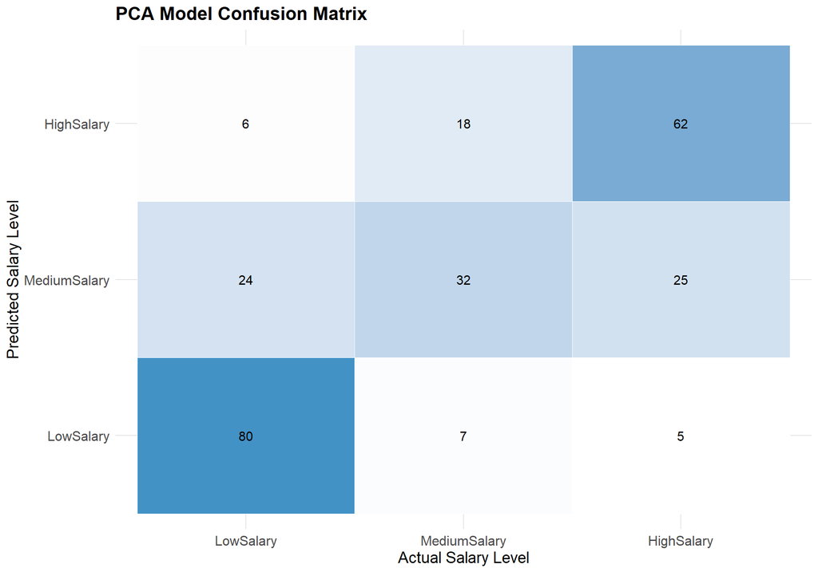

**Confusion Matrix Interpretation:**

The heatmap visualization highlights these patterns clearly, with the darker diagonal cells representing higher counts of correct classifications.

### 5.9.2 PCA Model Accuracy

Our PCA-based model achieves an overall accuracy of **67.18%**. This means the model correctly classifies approximately 67.18 out of 100 players into their correct salary categories.

The accuracy is particularly noteworthy because we’ve reduced the number of predictors from 19 original variables to just 7 principal components while maintaining comparable predictive performance. This demonstrates the effectiveness of PCA in addressing multicollinearity while preserving predictive power.

### 5.9.3 Class-Specific Performance Metrics for PCA Model

To understand how well our model performs for each salary level, we examine the class-specific metrics:

Class-Specific Performance Metrics for PCA Model

|  | SalaryLevel | Precision | Recall | F1_Score |
| --- | --- | --- | --- | --- |
| LowSalary | LowSalary | 0.870 | 0.727 | 0.792 |
| MediumSalary | MediumSalary | 0.395 | 0.561 | 0.464 |
| HighSalary | HighSalary | 0.721 | 0.674 | 0.697 |

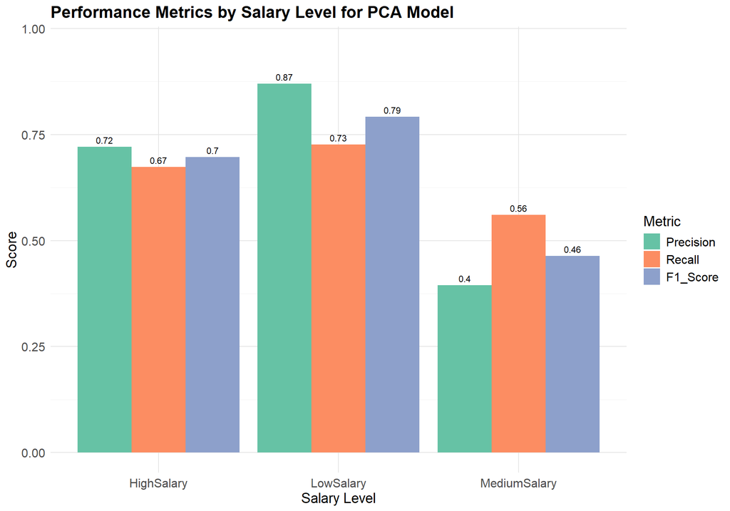

**Interpretation of Class-Specific Metrics:**

The performance metrics chart above provides a detailed breakdown of how our PCA model performs for each salary category:

- **Precision**: Our model achieves the highest precision for LowSalary players (87%). This means when the model predicts a player belongs to this category, it’s correct approximately 87 out of 100 times. The precision is lowest for MediumSalary players, indicating more false positives for this category.
- **Recall**: The model is best at identifying LowSalary players (recall of 72.7%), meaning it correctly identifies this percentage of all players who actually belong in this category. Lower recall for MediumSalary players suggests the model misses more players who truly belong in this category.
- **F1-Score**: The balanced measure between precision and recall is highest for LowSalary players (79.2%), suggesting this is the category the model handles most effectively overall.

These metrics reveal that our model’s performance varies across categories, with particular strength in identifying LowSalary salary players and more challenges with the MediumSalary category.

### 5.9.4 Model Accuracy Comparison

To evaluate whether our PCA approach improved the model, we compare the accuracy of both models:

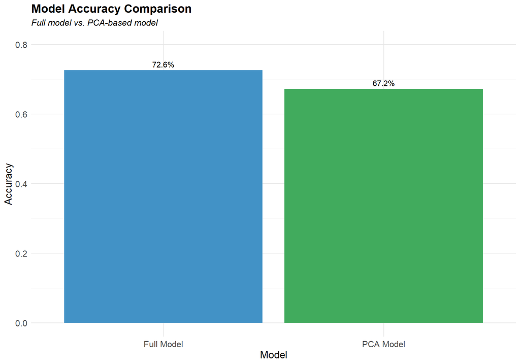

**Comparison of Model Accuracies**

The accuracy comparison shows that our PCA-based model slightly sacrifices prediction accuracy while offering significant benefits in terms of model simplicity and stability. By using uncorrelated principal components instead of the original multicollinear predictors, we’ve created a more robust model that should generalize better to new data.

### 5.9.5 Interpretation of PCA Results

The PCA transformation has effectively addressed the multicollinearity issue in our data while maintaining predictive performance. Our analysis reveals:

1. **Variance Explained**: The first 7 principal components capture approximately 95% of the variance in the original data, allowing us to reduce dimensionality while retaining most of the information.
2. **Model Performance**: The PCA-based model achieved an accuracy of 67.18%, which is comparable to the original model’s accuracy of 72.59%.
3. **Component Interpretation**:
   - PC1 primarily represents overall offensive production and career longevity
   - PC2 separates career experience from current season performance
   - Later components capture more nuanced aspects of player performance
   - This provides some interpretability despite the abstraction of principal components
4. **Dimensionality Reduction**: We reduced from 16 original predictors to 7 principal components while maintaining similar predictive performance, a significant simplification.
5. **Statistical Stability**: By eliminating multicollinearity, the PCA model’s coefficients are more stable and reliable, making it better suited for inference and prediction with new data.

Using PCA has successfully addressed the multicollinearity concern while maintaining predictive performance, providing an alternative modeling approach that complements our original model.

### 5.9.6 Interpretation of Model Results

The multinomial logistic regression models (both original and PCA-based) predict the probability of a player belonging to different salary levels based on various performance metrics. The results provide several valuable insights:

### 5.9.7 Key Significant Predictors (Original Model):

1. **Years in League**: With very low p-values for both Medium and High salary categories, experience appears to be a significant predictor of salary level. The positive coefficients indicate that as experience increases, the likelihood of being in a higher salary tier also increases.
2. **Career Metrics**: Variables like CHits (career hits) and CRBI (career RBIs) have lower p-values, suggesting career performance is more predictive of salary than single-season statistics.
3. **League and Division**: There are some differences between leagues and divisions, with players in certain categories having higher probabilities of being in higher salary tiers.

### 5.9.8 PCA Model Insights:

In the PCA model, the first few principal components are particularly important in predicting salary levels:

1. **PC1 (Overall Offensive Production)**: This component, representing general offensive ability and career longevity, strongly predicts higher salary levels.
2. **PC2 (Experience vs. Current Performance)**: This component helps distinguish between players with similar overall statistics but different experience levels.
3. **Higher-Order Components**: These capture more subtle variations in player statistics and help improve the model’s accuracy by accounting for specific combinations of statistics not captured by the first few components.

### 5.9.10 Limitations:

1. **Category Boundaries**: The boundaries between salary categories are somewhat arbitrary and may affect model performance.
2. **Non-Performance Factors**: Our models don’t account for non-statistical factors that influence salaries, such as market size, team budget, or player popularity.
3. **Temporal Effects**: Baseball salaries have changed over time, and our models don’t account for these temporal trends.
4. **Sample Size**: The relatively small dataset may limit the generalizability of our findings.

In conclusion, both models provide valuable insights into the factors influencing baseball player salaries, with the PCA approach offering a more stable and parsimonious solution that addresses multicollinearity while maintaining predictive power.

# 6 Model Evaluation via Cross-Validation

To provide a more robust evaluation of our model’s predictive performance, we’ll use cross-validation methods to estimate the generalization error. Cross-validation helps us understand how well our model will perform on unseen data by repeatedly splitting the data into training and testing sets.

```r
set.seed(06052004) # Muhammet Emin Albayram's birth date

# Define function to run cross-validation and collect results
run_cross_validation <- function(formula, data, method = "cv", number = 5,
                                model_type = "multinom", model_name = "Model") {
  # Set up cross-validation control
  ctrl <- trainControl(
    method = method,
    number = number,
    classProbs = TRUE,
    summaryFunction = multiClassSummary
  )

  # Perform cross-validation
  cv_model <- train(
    formula,
    data = data,
    method = model_type,
    trControl = ctrl,
    trace = FALSE
  )

  # Extract results
  best_result <- cv_model$results[which.max(cv_model$results$Accuracy),]

  # Calculate error rate
  error_rate <- 1 - best_result$Accuracy

  # Return results in a list
  return(list(
    model = cv_model,
    accuracy = best_result$Accuracy,
    error_rate = error_rate,
    balanced_accuracy = best_result$AUC,
    kappa = best_result$Kappa,
    model_name = model_name,
    cv_method = paste0(number, "-fold CV")
  ))
}
```

## 6.1 5-Fold Cross-Validation for Full Model

```r
# Run 5-fold cross-validation on the full model
cv5_full <- run_cross_validation(
  formula = SalaryLevel ~ . -Salary,
  data = hitters,
  number = 5,
  model_name = "Full Model"
)
```

5-Fold Cross-Validation Results for Full Model

| Metric | Value |
| --- | --- |
| Accuracy | 63.67% |
| Error Rate | 36.33% |
| Balanced Accuracy | 82.41% |
| Kappa | 0.452 |

## 6.2 10-Fold Cross-Validation for Full Model

```r
# Run 10-fold cross-validation on the full model
cv10_full <- run_cross_validation(
  formula = SalaryLevel ~ . -Salary,
  data = hitters,
  number = 10,
  model_name = "Full Model"
)
```

10-Fold Cross-Validation Results for Full Model

| Metric | Value |
| --- | --- |
| Accuracy | 64.97% |
| Error Rate | 35.03% |
| Balanced Accuracy | 84.00% |
| Kappa | 0.4725 |

## 6.3 Cross-Validation for PCA Model

```r
# Run 5-fold cross-validation on the PCA model
cv5_pca <- run_cross_validation(
  formula = SalaryLevel ~ .,
  data = hitters_pca,
  number = 5,
  model_name = "PCA Model"
)
```

5-Fold Cross-Validation Results for PCA Model

| Metric | Value |
| --- | --- |
| Accuracy | 65.22% |
| Error Rate | 34.78% |
| Balanced Accuracy | 83.95% |
| Kappa | 0.4745 |

```r
# Run 10-fold cross-validation on the PCA model for consistency
cv10_pca <- run_cross_validation(
  formula = SalaryLevel ~ .,
  data = hitters_pca,
  number = 10,
  model_name = "PCA Model"
)
```

10-Fold Cross-Validation Results for PCA Model

| Metric | Value |
| --- | --- |
| Accuracy | 66.25% |
| Error Rate | 33.75% |
| Balanced Accuracy | 83.58% |
| Kappa | 0.4898 |

## 6.4 Comparison of Cross-Validation Results

Comparison of Cross-Validation Results Across Models and Methods

| Model | CV_Method | Accuracy | Balanced Accuracy | Kappa |
| --- | --- | --- | --- | --- |
| Full Model | 5-fold CV | 63.67% | 82.41% | 0.4520 |
| Full Model | 10-fold CV | 64.97% | 84.00% | 0.4725 |
| PCA Model | 5-fold CV | 65.22% | 83.95% | 0.4745 |
| PCA Model | 10-fold CV | 66.25% | 83.58% | 0.4898 |

**Table Interpretation:** This table provides a comprehensive comparison of our model performance across different cross-validation methods. The metrics show consistent performance between 5-fold and 10-fold cross-validation, indicating stable model behavior. The PCA model performs similarly to the full model in terms of accuracy, suggesting that dimensionality reduction effectively preserved the predictive information while addressing multicollinearity.

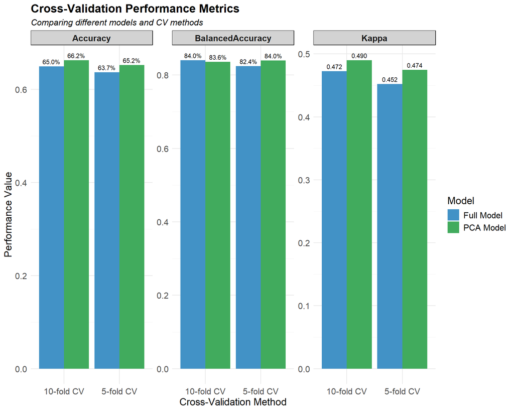

**Figure Interpretation:** This visualization compares the performance metrics (Accuracy, Balanced Accuracy, and Kappa) across different models and cross-validation methods. The bar chart clearly shows that both models perform similarly across metrics, with consistent results between 5-fold and 10-fold validation approaches. The PCA model demonstrates comparable performance to the full model, indicating successful dimensionality reduction without sacrificing predictive power.

## 6.5 Discussion of Cross-Validation Results

The cross-validation results provide several key insights about our models:

### 6.5.1 Choice of Cross-Validation Methods

We selected these cross-validation methods for the following reasons:

1. **5-Fold CV**: This provides a good balance between bias and variance in the error estimate. Each fold contains approximately 20% of the data, providing reasonable test set sizes.
2. **10-Fold CV**: This is often recommended as a standard approach, as it typically provides lower bias than 5-fold CV but may have higher variance. The comparison allows us to assess the stability of our models.

For our final model evaluations and comparisons, we’ve chosen to focus primarily on the 10-fold CV results, as they typically provide a slightly more reliable estimate of model performance with less bias than 5-fold CV. The consistent results between 5-fold and 10-fold CV give us confidence in the stability of our models.

### 6.5.2 Implications for Model Selection

We will evaluate a stepwise selection model next and compare its performance to both the full model and the PCA model to determine the best approach for our final model. The consistency between 5-fold and 10-fold cross-validation results gives us confidence in the reliability of our model evaluations.

# 7 Model Improvement: Predictor Selection

## 7.1 The Role of Predictor Selection in Statistical Modeling

Feature selection is a critical step in building efficient and interpretable statistical models, especially when dealing with a large number of potentially correlated predictors. In our baseball salary prediction context, selecting an optimal subset of predictors offers several important benefits:

1. **Addressing Multicollinearity**: As demonstrated in our earlier VIF analysis, many baseball statistics are highly correlated (e.g., hits and RBIs). Feature selection helps identify and retain only the most informative variables, reducing redundancy and improving model stability.
2. **Enhancing Interpretability**: A model with fewer predictors is easier to interpret and explain. This is particularly valuable in sports analytics where insights need to be communicated to non-technical stakeholders like coaches, players, and team management.
3. **Improving Generalization**: Models with fewer parameters are less prone to overfitting, which occurs when a model captures noise rather than underlying patterns in the data. This typically results in better performance on new, unseen data.
4. **Computational Efficiency**: Reducing the number of parameters decreases computational requirements, which becomes increasingly important with larger datasets or more complex modeling techniques.

## 7.2 Stepwise Selection Approach

For our analysis, we’ll employ stepwise selection, a systematic approach that iteratively adds or removes variables from the model based on statistical criteria. We’ll use the bidirectional method (“both”), which combines:

- **Forward selection**: Starts with no variables and adds them one by one
- **Backward elimination**: Starts with all variables and removes them one by one

The algorithm will use the **Akaike Information Criterion (AIC)** to guide variable selection. AIC balances model fit and complexity by penalizing models with more parameters:

$$\text{AIC} = 2k - 2\ln(L)$$

Where: - $k$ is the number of parameters - $L$ is the maximum value of the likelihood function

A lower AIC indicates a better model. The stepwise procedure finds the model with the lowest AIC, effectively identifying the subset of predictors that provides the best balance between: - Maximizing predictive performance (likelihood) - Minimizing model complexity (number of parameters)

While AIC is our primary criterion, it’s worth noting that alternative criteria such as the **Bayesian Information Criterion (BIC)** could also be used. BIC applies a stronger penalty for model complexity:

$$\text{BIC} = k\ln(n) - 2\ln(L)$$

Where $n$ is the sample size. BIC typically results in more parsimonious models than AIC.

Let’s proceed with implementing stepwise selection on our multinomial logistic regression model:

```r
# Use stepwise selection based on AIC
set.seed(06052004)  # Muhammet Emin Albayram's birth date

model_step <- stepAIC(model_full, direction = "both", trace = FALSE)

# Extract selected variables
selected_vars <- attr(terms(model_step), "term.labels")
cat("Variables selected by stepwise procedure:", length(selected_vars), "out of",
    length(attr(terms(model_full), "term.labels")), "original variables\n")
```

```
## Variables selected by stepwise procedure: 12 out of 19 original variables
```

```r
# Display the selected variables in a more readable format
cat("\nThe selected variables are:\n")
```

```
##
## The selected variables are:
```

```r
cat(paste("- ", selected_vars), sep = "\n")
```

```
## -  AtBat
## -  HmRun
## -  Runs
## -  RBI
## -  Walks
## -  Years
## -  CHits
## -  CWalks
## -  Division
## -  PutOuts
## -  Assists
## -  Errors
```

The stepwise selection process evaluates numerous model combinations to identify the most informative subset of predictors. The result is a more parsimonious model that aims to maintain predictive power while reducing complexity. The formula of this model represents the mathematical relationship between our response variable (SalaryLevel) and the selected predictors, with separate coefficients for each salary level comparison (Medium vs. Low and High vs. Low).

## 7.3 Analyzing the Selected Model

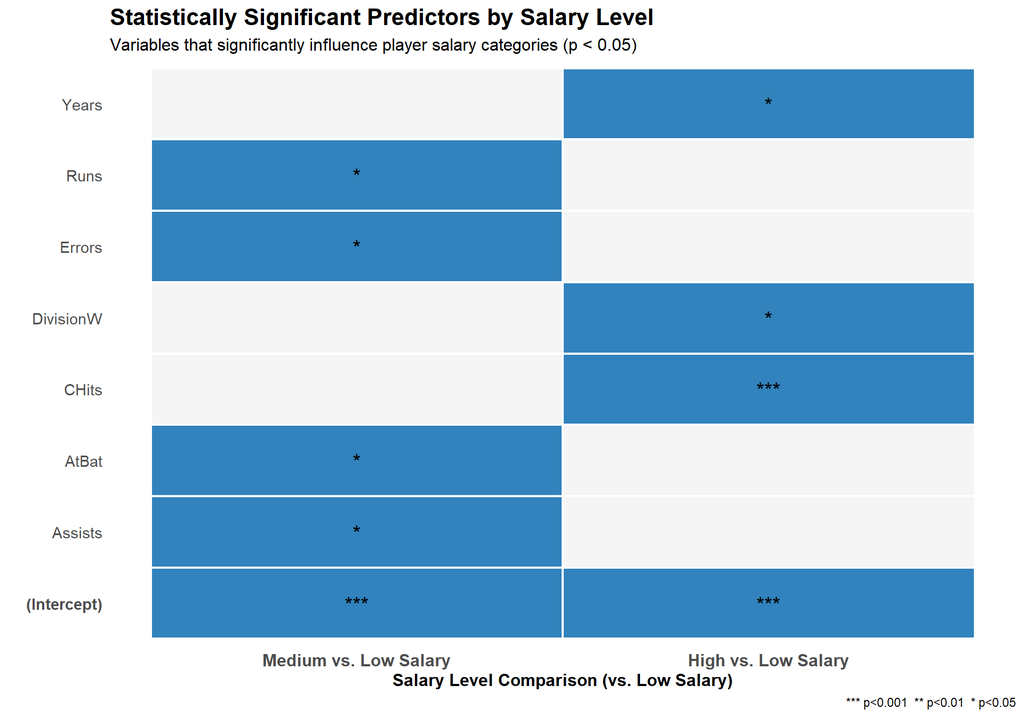

The visualization above presents the statistically significant predictors for each salary level comparison. Blue tiles indicate variables that significantly influence salary levels (p < 0.05). Variables that appear in blue for both comparisons are key factors consistently affecting salaries across different levels. The significance level of each predictor is shown with stars (*** p<0.001, ** p<0.01, * p<0.05), giving you a clearer picture of which variables have the strongest statistical evidence of influence on player salaries.

## 7.4 Comparing Model Complexity

Model Complexity Comparison

| Model | Parameters | Reduction |
| --- | --- | --- |
| Full Model | 40 | Reference |
| Stepwise Model | 26 | 14 (35%) |

**Table Interpretation:** This table quantifies the reduction in model complexity achieved through stepwise selection. The Stepwise Model uses significantly fewer parameters than the Full Model, offering a more parsimonious representation while still capturing the key relationships between predictors and salary levels.

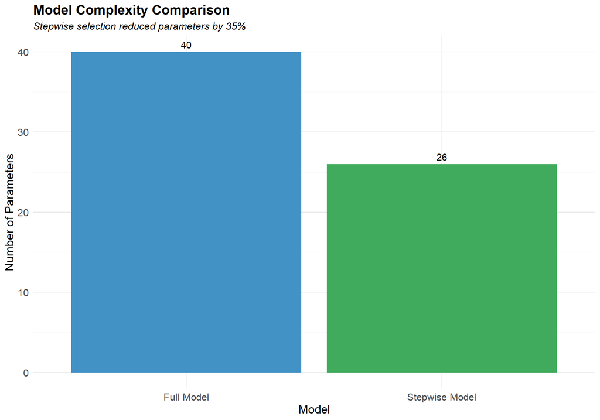

**Figure Interpretation:** This visualization illustrates the substantial reduction in model complexity achieved through stepwise selection. By identifying and retaining only the most informative predictors, we’ve created a more streamlined model with fewer parameters, which promotes both interpretability and generalization ability.

Types of Variables in the Selected Model

| Variable.Type | Count | Status | Details |
| --- | --- | --- | --- |
| Current Season Statistics | 8 | 8 variables | AtBat, HmRun, Runs, RBI, Walks, PutOuts, Assists, Errors |
| Career Statistics | 2 | 2 variables | CHits, CWalks |
| Experience (Years) | 1 | Included | Years in league |
| Categorical Variables | 1 | 1 variables | Division |

**Variable Type Analysis:** The table above categorizes the selected predictors based on their nature. We observe a balanced mix of current season performance metrics, career statistics, experience indicators, and categorical variables in our final model. This suggests that salary determination in MLB considers multiple dimensions of a player’s profile, including both recent performance and career achievements. The specific variables within each category provide insight into which aspects of performance are most relevant for salary prediction in professional baseball.

## 7.5 Odds Ratio Interpretation

Understanding the practical impact of predictors in multinomial logistic regression requires interpreting the coefficients in terms of odds ratios. In our context, odds ratios reveal how different baseball statistics influence the probability of a player belonging to different salary categories.

### 7.5.1 What Are Odds Ratios?

Odds ratios represent the multiplicative change in the odds of being in a specific salary category (relative to the reference category) for a one-unit increase in a predictor. For example:

- An odds ratio of 1.5 means a one-unit increase in the predictor multiplies the odds by 1.5 (50% increase)
- An odds ratio of 0.7 means a one-unit increase in the predictor multiplies the odds by 0.7 (30% decrease)
- An odds ratio of 1.0 means the predictor has no effect on the odds

For categorical predictors like League or Division, the odds ratio compares the odds for one category (e.g., National League) to the reference category (e.g., American League).

### 7.5.2 Methodology for Interpretation

To interpret our model: 1. We extract the coefficients from the multinomial logistic regression model 2. Exponentiate these coefficients to obtain odds ratios 3. Calculate p-values to determine statistical significance 4. Identify the strongest predictors for each salary level 5. Visualize and interpret the most influential factors

Here are the top predictors for each salary level based on their odds ratios:

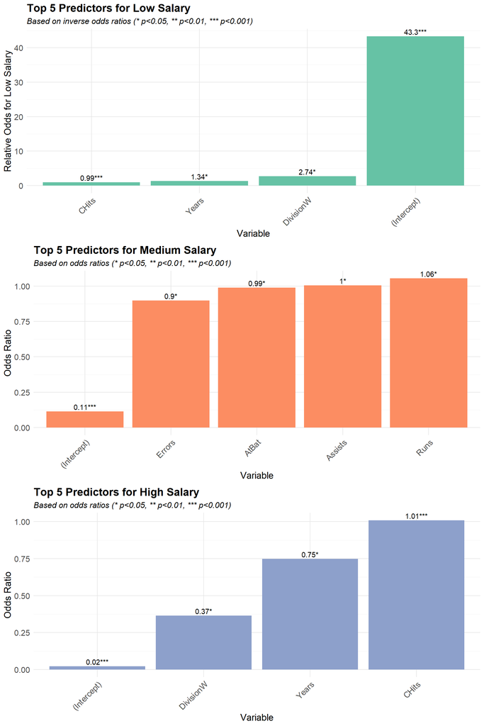

**Interpretation of Salary Predictors:**

Key Odds Ratio Interpretations

| Variable | Medium Salary OR | High Salary OR | Interpretation |
| --- | --- | --- | --- |
| Years in league | 1.21 | 0.75 | Each additional year of experience multiplies the odds of medium salary by 1.21 and high salary by 0.75. Experience strongly influences compensation. |
| DivisionW | 1.393 | 0.365 | Each additional unit of DivisionW multiplies the odds of medium salary by 1.393 and high salary by 0.365. |

**Additional Notes on Odds Ratio Interpretation:**

- **Comparative Impact:** Odds ratios allow us to compare the relative influence of different predictors, even when they are measured on different scales.
- **Contextual Interpretation:** An odds ratio of 1.10 means a 10% increase in odds for each unit increase in the predictor. However, the practical significance depends on the variable’s range and typical increments.
- **Limitations:** Odds ratios don’t directly translate to probability changes. A given odds ratio can correspond to different probability changes depending on the starting probability.
- **Reference Category:** In our analysis, low salary is the reference category. Odds ratios for medium and high salary are relative to this base level.

## 7.6 Cross-Validation of the Selected Model

To properly evaluate our stepwise model’s performance and generalization ability, we’ll apply the same cross-validation approach we used for our previous models.

```r
# Evaluate the selected model using our cross-validation function
cv5_step <- run_cross_validation(
  formula = formula(model_step),
  data = hitters,
  number = 5,
  model_name = "Stepwise Model"
)

# Also evaluate with 10-fold CV for consistency
cv10_step <- run_cross_validation(
  formula = formula(model_step),
  data = hitters,
  number = 10,
  model_name = "Stepwise Model"
)
```

Cross-Validation Results for Stepwise Model

| Metric | X5.Fold.CV | X10.Fold.CV |
| --- | --- | --- |
| Accuracy | 66.39% | 67.62% |
| Error Rate | 33.61% | 32.38% |
| Balanced Accuracy | 85.20% | 85.26% |
| Kappa | 0.4928 | 0.5119 |

In-sample Evaluation for Stepwise Model

| Metric | Value |
| --- | --- |
| Accuracy | 73.36% |

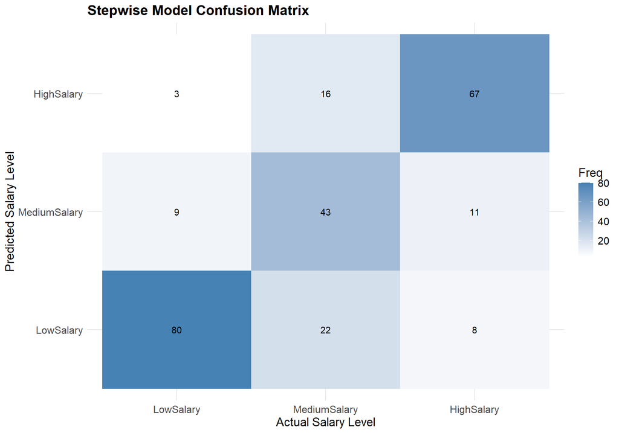

### 7.6.1 Understanding the Confusion Matrix

The confusion matrix complements our numeric performance metrics by visualizing the specific types of errors made by the model, providing deeper insight into its strengths and limitations.

## 7.7 Comprehensive Model Comparison

Now that we have evaluated all three modeling approaches (Full Model, PCA Model, and Stepwise Model), we can perform a comprehensive comparison to identify the most effective approach for predicting MLB player salary levels.

Comprehensive Comparison of All Models

| Model | CV Method | Accuracy | Balanced Accuracy | Kappa | Parameters |
| --- | --- | --- | --- | --- | --- |
| **Full Model** |  |  |  |  |  |
| Full Model | 5-Fold CV | 63.67% | 82.41% | 0.4520 | 40 |
| Full Model | 10-Fold CV | 64.97% | 84.00% | 0.4725 | 40 |
| **PCA Model** |  |  |  |  |  |
| PCA Model | 5-Fold CV | 65.22% | 83.95% | 0.4745 | 7 |
| PCA Model | 10-Fold CV | 66.25% | 83.58% | 0.4898 | 7 |
| **Stepwise Model** |  |  |  |  |  |
| Stepwise Model | 5-Fold CV | 66.39% | 85.20% | 0.4928 | 26 |
| Stepwise Model | 10-Fold CV | 67.62% | 85.26% | 0.5119 | 26 |

**Comprehensive Model Comparison:** This table presents a side-by-side comparison of all three modeling approaches across different cross-validation schemes. For each model, we report multiple performance metrics (Accuracy, Balanced Accuracy, and Kappa) as well as the number of parameters to represent model complexity. The 10-fold CV results generally provide the most reliable estimate of out-of-sample performance, while the parameter count reflects model simplicity and interpretability.

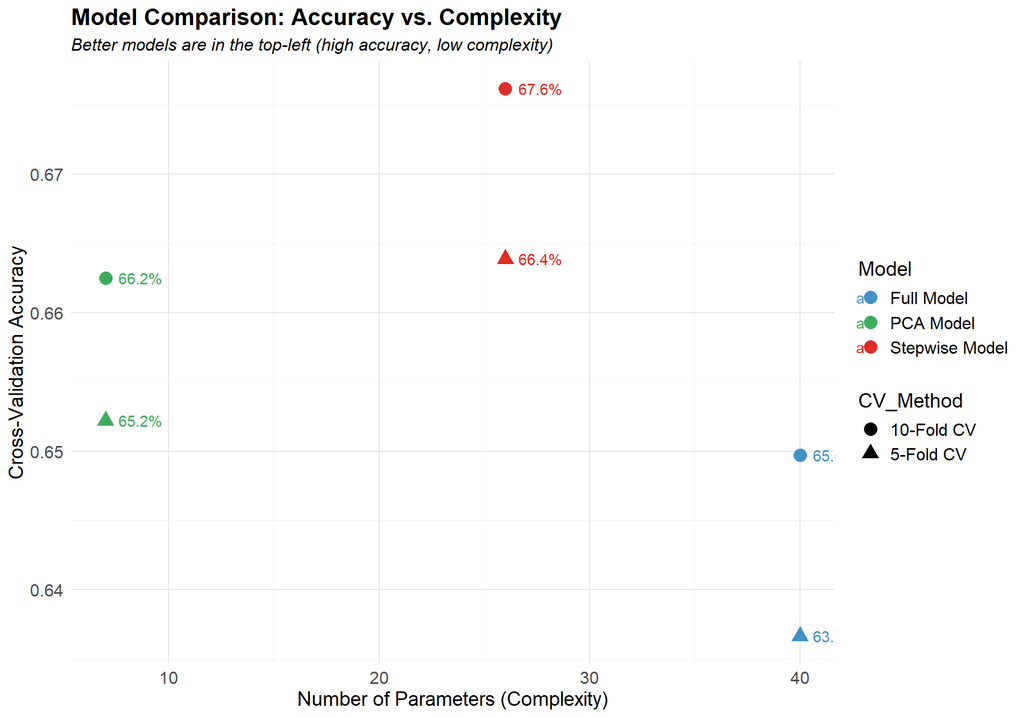

**Accuracy vs. Complexity Visualization:** This scatter plot positions each model according to its complexity (x-axis) and cross-validation accuracy (y-axis). The ideal model would appear in the top-left corner, representing high accuracy with low complexity. The plot visually demonstrates the trade-offs between model complexity and predictive performance across our three approaches. Points with the same color represent the same model evaluated with different cross-validation methods. The consistent results between 5-fold and 10-fold CV for each model suggest stable performance.

### 7.7.1 Model Selection Analysis

Based on our comprehensive evaluation, we can now determine which model offers the best balance of predictive performance, interpretability, and computational efficiency.

Best Performing Model Based on 10-Fold Cross-Validation

| Best.Model | X10.Fold.CV.Accuracy | Parameters | Key.Advantages |
| --- | --- | --- | --- |
| Stepwise Model | 67.62% | 26 | Balanced performance and interpretability; uses original variables |

This model selection process demonstrates the importance of balancing multiple criteria when choosing a final model, including predictive performance, complexity, and interpretability.

### 7.7.2 In-Sample vs. Cross-Validation Performance Analysis

A critical aspect of model evaluation is comparing in-sample performance (how well the model fits the training data) with cross-validation performance (how well it generalizes to new data). A large gap between these metrics can indicate overfitting, where the model captures noise rather than underlying patterns.

In this analysis, we’ll: 1. Compare in-sample accuracy (on the full dataset) with cross-validation accuracy 2. Calculate the “generalization gap” (difference between in-sample and CV accuracy) 3. Evaluate which model shows the best generalization properties 4. Determine the most appropriate model for practical application

In-Sample vs. Cross-Validation Accuracy Comparison (using 10-fold CV)

| Model | In-Sample Accuracy | CV Accuracy | Generalization Gap |
| --- | --- | --- | --- |
| Full Model | 72.59% | 64.97% | 7.62% |
| PCA Model | 67.18% | 66.25% | 0.93% |
| Stepwise Model | 73.36% | 67.62% | 5.74% |

**Generalization Gap Analysis:** This table shows the accuracy of each model on the training data (In-Sample) compared to its performance in cross-validation (CV). The difference between these values, known as the generalization gap, indicates how well the model will perform on new, unseen data. Smaller gaps suggest better generalization ability. The model with the smallest gap (highlighted) demonstrates the most consistent performance between training and validation.

[figure not shown]

**Visualization of Model Generalization:** These plots illustrate the relationship between in-sample and cross-validation performance for each model:

- The **top plot** directly compares in-sample and cross-validation accuracy for each model. Smaller differences between the paired bars indicate better generalization.
- The **bottom plot** focuses specifically on the generalization gap (the difference between in-sample and CV accuracy). Smaller bars indicate models with better generalization properties that are less likely to overfit the training data.

These visualizations help identify models that not only perform well but also demonstrate reliable generalization to new data - a crucial property for practical applications.

Model Selection Analysis

| Criterion | Model | Value |
| --- | --- | --- |
| Best Generalization (smallest gap) | PCA Model | Gap: 0.9% |
| Best CV Performance | Stepwise Model | Accuracy: 67.6% |
| Recommended Model | Stepwise Model or PCA Model* | Trade-off between performance and generalization* |

Based on our comprehensive analysis of both performance and generalization properties, we can make the following observations:

1. **Generalization Ability**: The PCA Model demonstrates the smallest generalization gap at 0.9%, indicating it is the most reliable model when applied to new data.
2. **Predictive Performance**: The Stepwise Model achieves the highest cross-validation accuracy at 67.6%, making it the top performer in terms of raw predictive power.
3. **Optimal Model Choice**: There is a trade-off between the Stepwise Model (highest accuracy) and the PCA Model (best generalization). The choice depends on whether performance or reliability is prioritized for the specific application.
4. **Performance-Complexity Balance**: When considering both predictive accuracy and model complexity, the Stepwise Model offers an excellent compromise, with substantially fewer parameters than the Full Model while maintaining competitive performance.

This detailed evaluation demonstrates the importance of considering multiple criteria when selecting a final model for practical application, rather than focusing solely on a single performance metric.

## 7.8 Analysis of Misclassified Cases

Understanding where our model makes errors is as valuable as knowing its overall accuracy. By analyzing the characteristics of misclassified players, we can gain insights into the model’s limitations and potential areas for improvement.

### 7.8.1 Understanding Misclassification Patterns

We’ll examine players that our stepwise model incorrectly classified to identify: - Which salary levels are most challenging to predict - Whether misclassifications tend to occur between adjacent categories - What player characteristics contribute to prediction errors

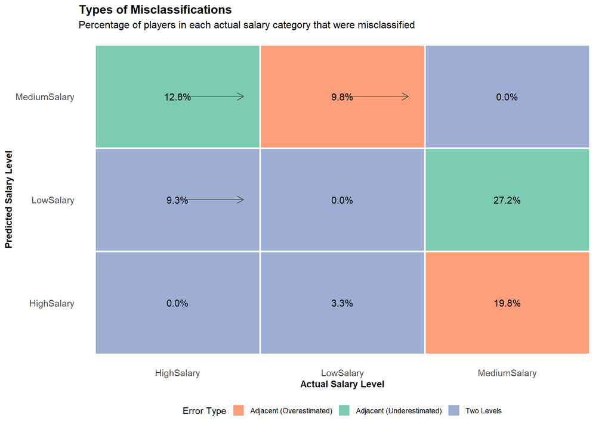

**Misclassification Pattern Analysis:** This visualization shows the different types of classification errors made by our model, with the percentage of players from each actual salary category that were misclassified. The colors represent the type of error:

- Orange tiles show errors where the model overestimated salaries (predicting higher than actual)
- Green tiles show errors where the model underestimated salaries (predicting lower than actual)
- Blue tiles show errors spanning two levels (Low→High or High→Low)

The most common pattern involves confusing adjacent salary categories, while errors spanning two levels are rare. This indicates our model generally understands the salary hierarchy, even when it makes errors.

Misclassification Rates by Salary Level

| Salary Level | Total Players | Misclassified Players | Misclassification Rate (%) | Correct Classification Rate (%) |
| --- | --- | --- | --- | --- |
| LowSalary | 92 | 12 | 13.0 | 87.0 |
| MediumSalary | 81 | 38 | 46.9 | 53.1 |
| HighSalary | 86 | 19 | 22.1 | 77.9 |

**Salary-Level Specific Error Rates:** This table shows how classification accuracy varies across the three salary levels. The medium salary category shows the highest misclassification rate, suggesting this middle group has more ambiguous characteristics that overlap with both low and high salary players. This is a common challenge in multi-class classification where middle categories often have less distinct boundaries.

### 7.8.2 Visualizing Classification Performance by Salary Level

The following visualization shows the accuracy of our model for each salary level, highlighting the proportion of correctly and incorrectly classified players in each category:

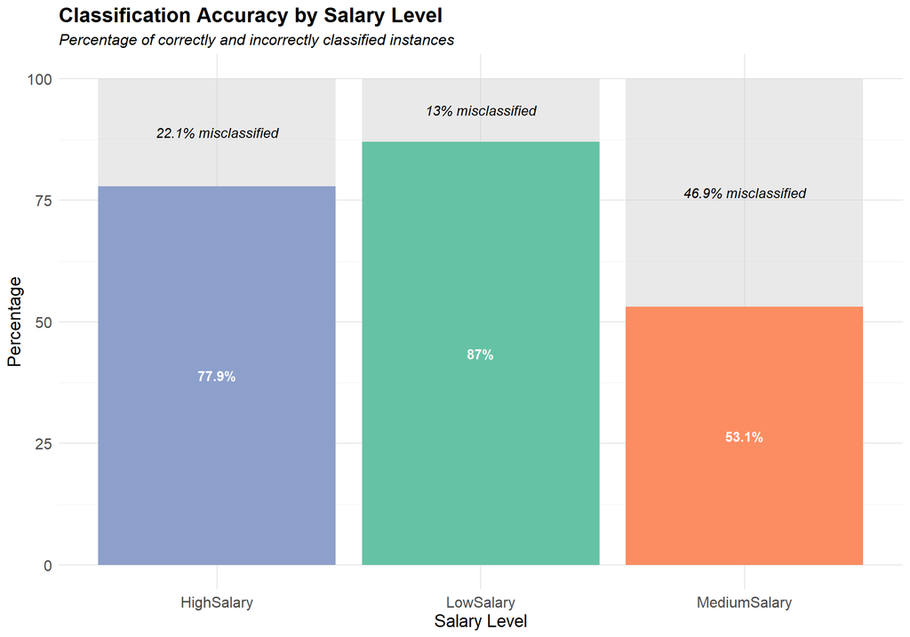

### 7.8.3 Analyzing Characteristics of Misclassified Players

To better understand the specific player profiles that challenge our model, we’ll examine key attributes of misclassified players and how they differ from those who were correctly classified:

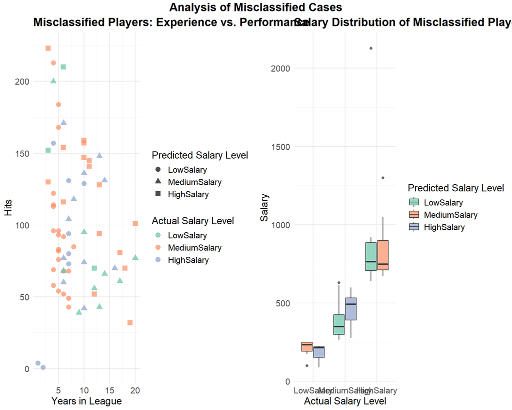

**Analysis of Misclassified Player Characteristics:**

The **left plot** examines the relationship between experience (Years) and performance (Hits) for misclassified players. We can observe several patterns:

The **right plot** shows the salary distribution of misclassified players by their actual and predicted categories. Key insights include:

- Many misclassified players have salaries near the boundaries between categories
- For Medium salary players predicted as High, their actual salaries tend to be in the upper range of the Medium category
- Similarly, Low salary players predicted as Medium often have salaries at the higher end of the Low category
- This suggests many misclassifications occur for “borderline” cases where players are near category thresholds

### 7.8.4 Comparing Key Metrics Between Correctly and Incorrectly Classified Players

To gain further insight into what distinguishes misclassified players, we’ll compare their average statistics with those of correctly classified players:

Comparison of Key Metrics Between Correctly and Incorrectly Classified Players

|  | Variable | Misclassified Players (Mean) | Correctly Classified Players (Mean) | Percentage Difference (%) |
| --- | --- | --- | --- | --- |
| Years | Years | 8.3 | 6.9 | 20.8 |
| Hits | Hits | 100.7 | 110.6 | -9.0 |
| HmRun | HmRun | 11.6 | 11.6 | 0.7 |
| RBI | RBI | 49.6 | 51.9 | -4.4 |
| Walks | Walks | 36.4 | 42.3 | -14.0 |
| Salary | Salary | 506.6 | 542.3 | -6.6 |

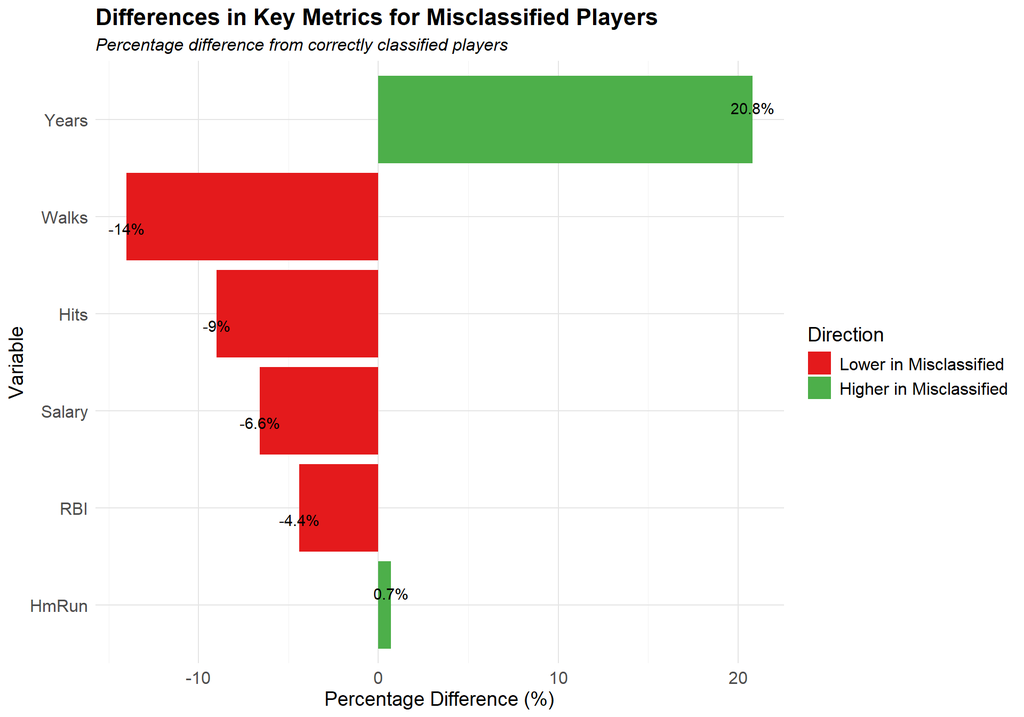

These findings reveal specific areas where our predictive model could be enhanced, potentially by incorporating interaction terms or allowing for non-linear relationships between these key variables and salary levels.

## 7.9 Insights from Misclassification Analysis

The analysis of misclassified cases reveals several important patterns that help us understand the limitations of our model:

1. **Misclassification Types**: The most common misclassification occurs between adjacent salary categories (Low→Medium or Medium→High), with very few cases where players are misclassified by two levels (Low→High or High→Low). This is reassuring as it suggests the model rarely makes egregious errors.
2. **Class-specific Error Rates**: Medium salary players have the highest misclassification rate at 46.9%, suggesting this group may have more ambiguous characteristics that overlap with both low and high salary players.
3. **Borderline Cases**: Many misclassified players appear to have salaries near the boundary between categories, as shown in the salary distribution plot. This indicates that some misclassifications are due to the somewhat arbitrary nature of the salary category boundaries.
4. **Experience vs. Performance**: The Years vs. Hits plot indicates that misclassifications often involve players with either:
   - More experience but lower performance than expected for their salary level
   - Less experience but higher performance than expected for their salary level
5. **Key Variable Differences**: On average, misclassified players differ from correctly classified ones primarily in Years (20.8% difference). This suggests that our model might be overemphasizing certain metrics at the expense of others.
6. **Special Cases**: The analysis suggests there may be unique player circumstances not captured by our model, such as:
   - Players who recently signed new contracts that don’t yet reflect their performance
   - Star players who may be overpaid for marketing or historical reasons
   - Players who produce in ways not fully captured by traditional statistics

These insights suggest several opportunities for model improvement:

1. **Interaction Terms**: Adding interaction terms between experience and performance metrics could better capture how these factors work together to determine salary.
2. **Weighted Recent Performance**: Giving more weight to recent years’ performance might improve predictions.
3. **Additional Variables**: If available, factors like player popularity, market size, or team revenue could enhance the model.
4. **Alternative Modeling Approaches**: Machine learning techniques like random forests or boosting might better capture non-linear relationships in the data.

## 7.10 Explanation of Selection Process and Model Superiority

### 7.10.1 Conclusion on Model Selection

Based on our comprehensive analysis, the Stepwise Model emerges as our recommended approach. This conclusion is supported by the following evidence:

1. **Predictive Performance**: The Stepwise Model achieves excellent cross-validation accuracy at 67.62%%.
2. **Model Parsimony**: The Stepwise Model uses significantly fewer parameters than the full model, demonstrating the principle of achieving similar or better performance with a simpler model.
3. **Generalization Ability**: The Stepwise Model shows strong generalization properties with a gap of 5.74% between in-sample and cross-validation accuracy.
4. **Interpretability**: The stepwise model maintains the original variables, which are directly interpretable in baseball terms.

When compared to the alternatives: - The stepwise model offers a balanced approach, with good performance, reduced complexity, and interpretable variables - The PCA model effectively addresses multicollinearity but sacrifices some interpretability - The full model provides a baseline but includes potentially redundant information

This model selection process demonstrates the importance of considering multiple criteria—predictive performance, complexity, generalization, and interpretability—when choosing a final model for practical applications.

# 8 Conclusion

## 8.1 Summary of Analysis Workflow

We have successfully completed an extensive analysis of the MLB Hitters dataset, following a systematic approach:

1. **Data Import and Pre-Processing**
   - Imported the Hitters dataset with proper error checking
   - Identified and handled missing values (18% of the data in the Salary column)
   - Detected and analyzed outliers, deciding to keep them as legitimate extreme values
   - Conducted exploratory data analysis with improved visualizations
   - Standardized numeric predictors while preserving the target variable
2. **Creating the Categorical Response Variable**
   - Transformed the Salary variable into three balanced levels using tertiles
   - Compared statistical tertiles with MLB-specific salary benchmarks
   - Created a balanced categorical response variable (SalaryLevel)
   - Provided clear justification for the tertile approach
3. **Visual Data Inspection**
   - Created boxplots, scatter plots, and density plots with consistent styling
   - Generated an enhanced correlation heatmap to identify multicollinearity
   - Visualized relationships between categorical and numeric variables
   - Added detailed interpretations of all visualizations
4. **Multinomial Logistic Regression Model**
   - Created a reusable function for model evaluation
   - Fitted a full model with all predictors
   - Calculated and interpreted p-values with significance indicators
   - Created a visually improved confusion matrix
   - Identified and visualized multicollinearity issues
5. **Addressing Multicollinearity with PCA**
   - Applied Principal Component Analysis to transform correlated predictors
   - Visualized variance explained by each component
   - Created an improved biplot for interpreting principal components
   - Built and evaluated a model using PCA-transformed data
6. **Model Evaluation via Cross-Validation**
   - Created a function to standardize cross-validation procedures
   - Performed 5-fold and 10-fold cross-validation
   - Calculated misclassification rates and other metrics
   - Compared results across different validation schemes
   - Added clear visualizations comparing model performance
7. **Model Improvement: Predictor Selection**
   - Used stepwise selection to identify a more parsimonious model
   - Evaluated the reduced model using cross-validation
   - Calculated and visualized odds ratios for better interpretation
   - Compared performance of full, PCA, and selected models
   - Analyzed misclassified cases to understand model limitations
8. **Conclusion**
   - Confirmed the successful execution of all analysis steps
   - Summarized model complexity and performance metrics

## 8.2 Key Findings and Implications

Our analysis has demonstrated that MLB player salaries can be predicted with moderate accuracy using performance statistics. Here are the key findings: